# N741 Spring 2018 - Homework 7 - ANSWER KEY

### Create Plots of How Well Each Variable Predicts CESD

Using the code below, we can see how well each variable predicts CESD scores.

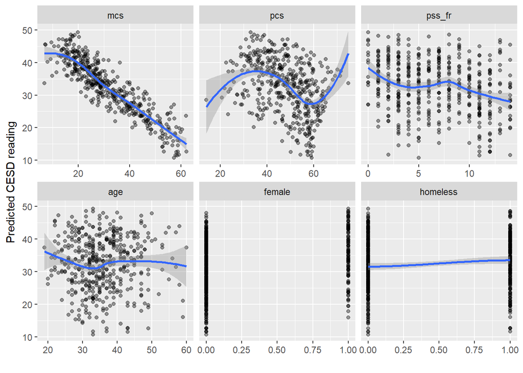

```r
#Create the variable dependence object from the random forest
gg_v_cesd <- ggRandomForests::gg_variable(fitallrf_cesd)

# Use the top ranked minimal depth variables only, plotted in minimal depth rank order
xvar <- gg_md_cesd$topvars

# Plot the variable list in a single panel plot
plot(gg_v_cesd, xvar = xvar, panel = TRUE, alpha = 0.4) +
  labs(y="Predicted CESD reading", x="")
```

### **PROBLEM 10: Create Plots of How Well Each Variable Predicts MCS**

Using the code above, see how well each variable predicts MCS scores given the other variables in the dataset `h1`.

### ANSWER KEY - Problem 10

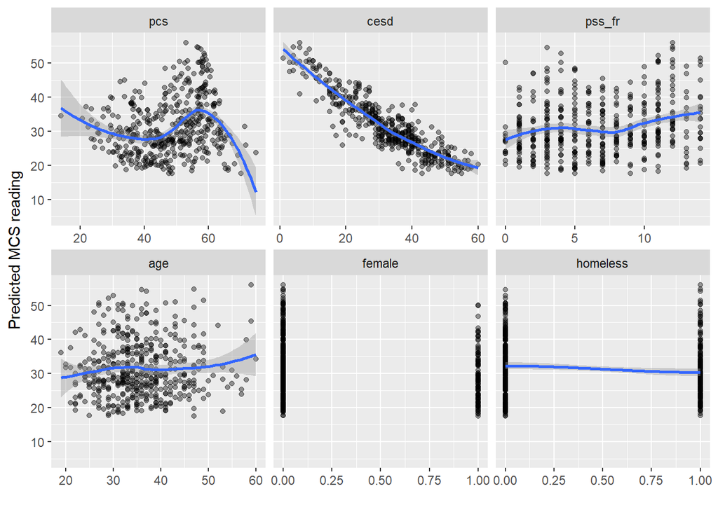

```r
# place code for problem 10 here

#Create the variable dependence object from the random forest
gg_v_mcs <- ggRandomForests::gg_variable(fitallrf_mcs)

# Use the top ranked minimal depth variables only, plotted in minimal depth rank order
xvar <- gg_md_mcs$topvars

# Plot the variable list in a single panel plot
plot(gg_v_mcs, xvar = xvar, panel = TRUE, alpha = 0.4) +
  labs(y="Predicted MCS reading", x="")
```

**Use R markdown to complete your homework and show all of your code and output in your final report - Turn in a PDF of your report to Canvas. Include a link to your Github repo for Homework 7**